# Assignment 5

hp621@scaretletmail.rutgers.edu

10/28/2022

```r
#Importing Data set and view data set

library(readxl)
HH_NatrualGAS <- read_excel("C:/Users/HARSH/Desktop/RU/BF/assignment4/HH_NatrualGAS.xlsx",
    col_types = c("date", "numeric"))
View(HH_NatrualGAS)
```

```r
#we use these libraries for Decomposition
library(fpp)
library(fpp2)
library(UsingR)
library(xts)
library(TTR)
```

```r
#Check your dataset in time series
head(HH_NatrualGAS)
```

```
## # A tibble: 6 × 2
##   Date                Price
##   <dttm>              <dbl>
## 1 1997-01-01 00:00:00  3.45
## 2 1997-02-01 00:00:00  2.15
## 3 1997-03-01 00:00:00  1.89
## 4 1997-04-01 00:00:00  2.03
## 5 1997-05-01 00:00:00  2.25
## 6 1997-06-01 00:00:00  2.2
```

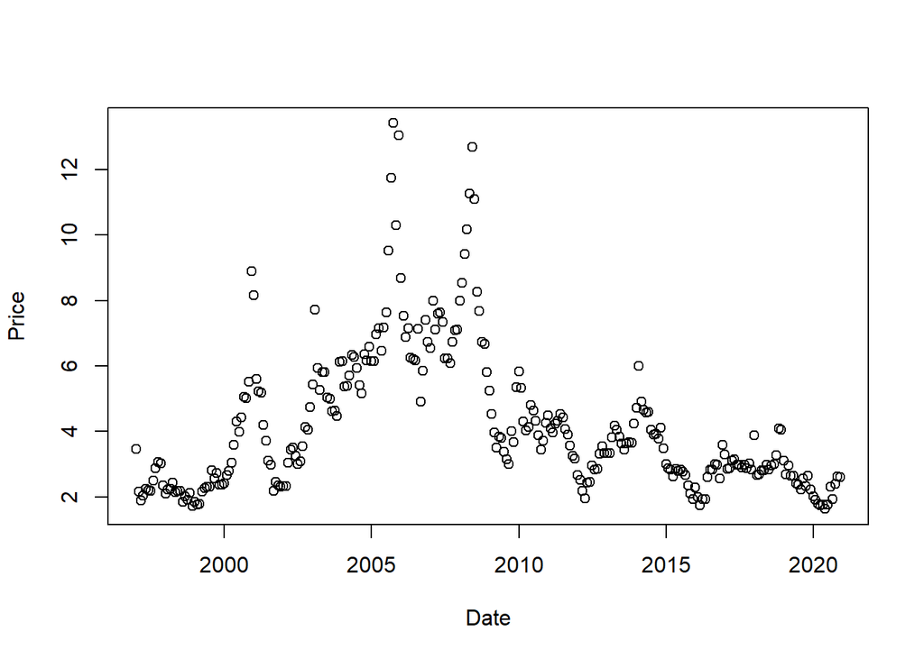

```r
plot(HH_NatrualGAS)
```

```r
ts_data <- ts(HH_NatrualGAS$Price, start = c(1997, 01),end = c(2020,12), frequency = 12)
summary(HH_NatrualGAS)
```

```
##       Date                         Price
##  Min.   :1997-01-01 00:00:00   Min.   : 1.630
##  1st Qu.:2002-12-24 06:00:00   1st Qu.: 2.647
##  Median :2008-12-16 12:00:00   Median : 3.520
##  Mean   :2008-12-15 17:00:00   Mean   : 4.182
##  3rd Qu.:2014-12-08 18:00:00   3rd Qu.: 5.275
##  Max.   :2020-12-01 00:00:00   Max.   :13.420
```

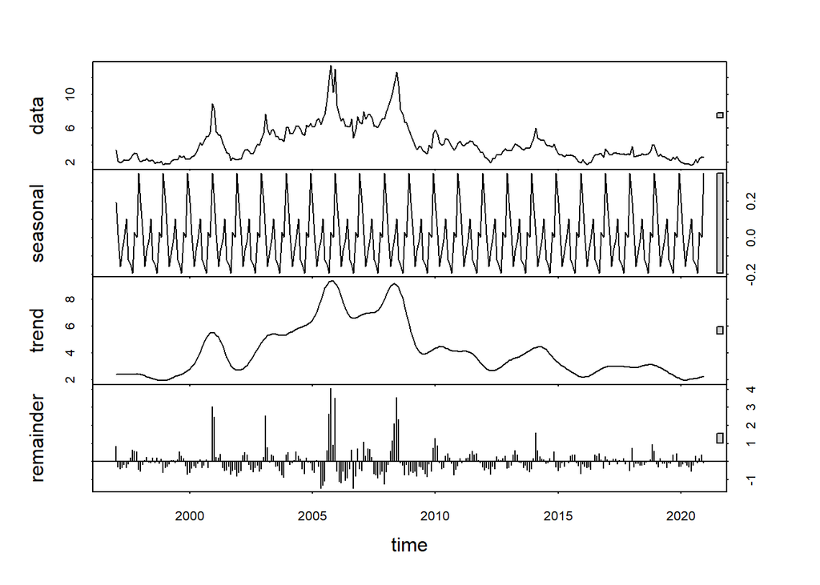

```r
#perform seasonal decomposition STL
stl_decomp <- stl(ts_data,s.window ="periodic")
#plot the decomposed components
plot(stl_decomp)
```

```r
#print attributes of the decomposition
attributes(stl_decomp)
```

```
## $names
## [1] "time.series" "weights"     "call"        "win"         "deg"
## [6] "jump"        "inner"       "outer"
##
## $class
## [1] "stl"
```

```r
# Lets print out a seasonal adjustment
seasadj(stl_decomp)
```

```
##            Jan       Feb       Mar       Apr       May       Jun       Jul
## 1997  3.256604  2.134930  2.047424  2.100856  2.261371  2.098262  2.309737
## 1998  1.896604  2.214930  2.397424  2.500856  2.151371  2.068262  2.289737
## 1999  1.656604  1.754930  1.947424  2.220856  2.271371  2.198262  2.429737
## 2000  2.226604  2.644930  2.947424  3.110856  3.601371  4.188262  4.109737
## 2001  7.976604  5.594930  5.387424  5.260856  4.201371  3.618262  3.229737
## 2002  2.126604  2.304930  3.187424  3.500856  3.511371  3.158262  3.109737
## 2003  5.236604  7.694930  6.087424  5.330856  5.821371  5.718262  5.149737
## 2004  5.946604  5.354930  5.547424  5.780856  6.341371  6.168262  6.049737
## 2005  5.956604  6.124930  7.117424  7.230856  6.481371  7.078262  7.749737
## 2006  8.496604  7.524930  7.047424  7.230856  6.261371  6.108262  6.289737
## 2007  6.356604  7.984930  7.267424  7.670856  7.651371  7.248262  6.339737
## 2008  7.796604  8.524930  9.567424 10.250856 11.281371 12.588262 11.209737
## 2009  5.046604  4.504930  4.117424  3.570856  3.841371  3.698262  3.499737
## 2010  5.636604  5.304930  4.447424  4.100856  4.151371  4.698262  4.749737
```

[output cut: 35 more lines]

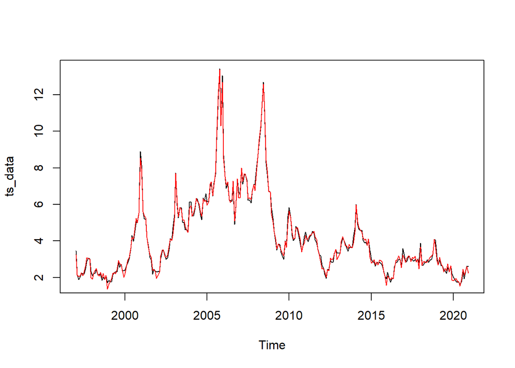

```r
# Plot a line on the graph
plot(ts_data)
lines(seasadj(stl_decomp), col="Red")
```

```r
# Default period forecast
f_stl <- forecast(stl_decomp)
# you can pass the # of period
f_stl <- forecast(stl_decomp,h=15)
f_stl
```

```
##          Point Forecast     Lo 80    Hi 80      Lo 95    Hi 95
## Jan 2021       2.437251 2.0342999 2.840201  1.8209907 3.053511
## Feb 2021       2.258925 1.6913833 2.826466  1.3909452 3.126904
## Mar 2021       2.086431 1.3901104 2.782752  1.0215003 3.151362
## Apr 2021       2.172999 1.3663356 2.979663  0.9393136 3.406685
## May 2021       2.232484 1.3271157 3.137852  0.8478428 3.617125
## Jun 2021       2.345593 1.3496619 3.341523  0.8224480 3.868737
## Jul 2021       2.124118 1.0436888 3.204547  0.4717442 3.776491
## Aug 2021       2.098419 0.9382036 3.258634  0.3240228 3.872815
## Sep 2021       2.051470 0.8152423 3.287697  0.1608230 3.942117
## Oct 2021       2.273696 0.9645482 3.582844  0.2715271 4.275866
## Nov 2021       2.248422 0.8689315 3.627913  0.1386731 4.358172
## Dec 2021       2.596452 1.1487974 4.044107  0.3824551 4.810450
## Jan 2022       2.437251 0.9232938 3.951208  0.1218535 4.752648
## Feb 2022       2.258925 0.6802714 3.837578 -0.1554171 4.673266
## Mar 2022       2.086431 0.4444762 3.728386 -0.4247223 4.597585
```

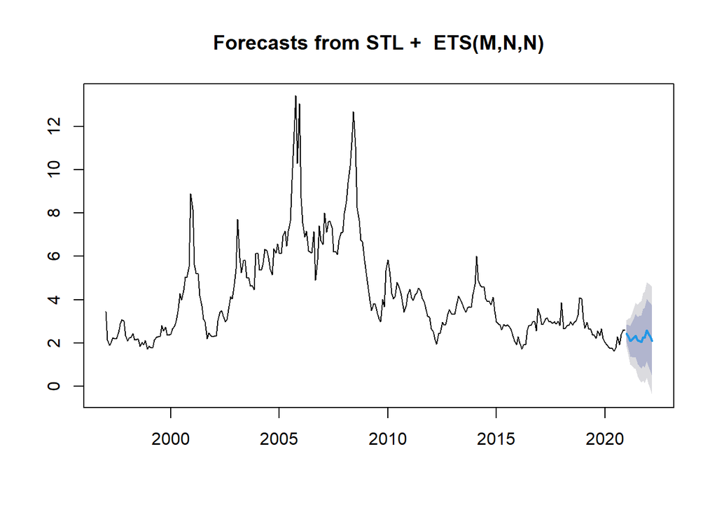

```r
plot(f_stl)
```

```r
# There is more than one way to do things
decomp_ts_data <- decompose(ts_data)

# Each one shows different attributes
attributes(decomp_ts_data)
```

```
## $names
## [1] "x"        "seasonal" "trend"    "random"   "figure"   "type"
##
## $class
## [1] "decomposed.ts"
```

```r
seasadj(decomp_ts_data)
```

```
##            Jan       Feb       Mar       Apr       May       Jun       Jul
## 1997  3.294789  2.124118  2.031600  2.084281  2.249716  2.080296  2.301691
## 1998  1.934789  2.204118  2.381600  2.484281  2.139716  2.050296  2.281691
## 1999  1.694789  1.744118  1.931600  2.204281  2.259716  2.180296  2.421691
## 2000  2.264789  2.634118  2.931600  3.094281  3.589716  4.170296  4.101691
## 2001  8.014789  5.584118  5.371600  5.244281  4.189716  3.600296  3.221691
## 2002  2.164789  2.294118  3.171600  3.484281  3.499716  3.140296  3.101691
## 2003  5.274789  7.684118  6.071600  5.314281  5.809716  5.700296  5.141691
## 2004  5.984789  5.344118  5.531600  5.764281  6.329716  6.150296  6.041691
## 2005  5.994789  6.114118  7.101600  7.214281  6.469716  7.060296  7.741691
## 2006  8.534789  7.514118  7.031600  7.214281  6.249716  6.090296  6.281691
## 2007  6.394789  7.974118  7.251600  7.654281  7.639716  7.230296  6.331691
## 2008  7.834789  8.514118  9.551600 10.234281 11.269716 12.570296 11.201691
## 2009  5.084789  4.494118  4.101600  3.554281  3.829716  3.680296  3.491691
## 2010  5.674789  5.294118  4.431600  4.084281  4.139716  4.680296  4.741691
```

[output cut: 35 more lines]

Data Loading: You first load the necessary libraries, read the time series data from an Excel file, and view the data.

Check Time Series Data: You examine the first few rows of the data and create a time series object (ts_data) with a specified start and end date and a frequency of 12 (monthly data). You also print a summary of the dataset.

Seasonal Decomposition (STL): You perform seasonal decomposition using the stl function. The stl_decomp object contains the decomposed components of the time series, including seasonal, trend, and remainder components. You plot the decomposed components for visualization.

Seasonal Adjustment: You print the seasonal adjustment using the seasadj function on the stl_decomp. Then, you overlay the seasonal adjustment on the original time series plot.

Forecasting: You generate forecasts using the forecast function on the stl_decomp. The first forecast is created with the default number of periods, and the second one is created with a specific number of periods (15 in this case). You also plot the forecasted values.

Alternative Decomposition: You perform another decomposition using the decompose function on the ts_data. This results in a different decomposition, and you check the attributes of the decomposed data and print the seasonal adjustment.